# Phasors

In the circuit given below, $V_S(t) = 100\,\cos \,(\omega \,t + 60^{\circ})$, $I_S(t) = 10\,\cos \,(\omega \,t + 30^{\circ})$, and the frequency is $50\,$Hz.

1. Find $R$ and $L$.
2. Determine $P$ and $Q$ delivered to the load.
3. Show that the instantaneous power $p(t)$ has a maximum $P + \sqrt{P^2+Q^2}$ and a minimum $P - \sqrt{P^2+Q^2}$. Verify with simulation results.

(Follow the convention that $\cos\,(\omega \,t)$ corresponds to the phasor $1\,\angle {0}$.)

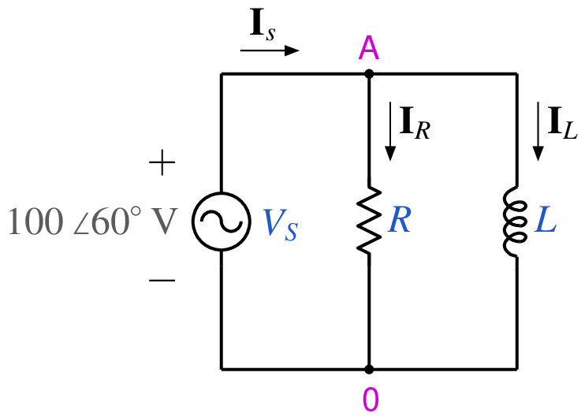

```python
from IPython.display import Image
Image(filename =r'phasor_11_fig_1.png', width=280)
```

```python
# run this cell to view the circuit file.
%pycat phasor_11_orig.in
```

We now replace the strings \$R and \$L with the values of our choice by running the python script given below. It takes an existing circuit file `phasor_11_orig.in` and produces a new circuit file `phasor_11.in`, after replacing \$R and \$L with the values of our choice.

```python
import gseim_calc as calc
s_R = '20' # to be changed by user
s_L = '40m' # to be changed by user
l = [
  ('$R', s_R),
  ('$L', s_L),
]
calc.replace_strings_1("phasor_11_orig.in", "phasor_11.in", l)
print('phasor_11.in is ready for execution')
```

```
phasor_11.in is ready for execution
```

**Execute the following cell to run GSEIM on phasor_11.in.**

```python
import os
import dos_unix
# uncomment for windows:
#dos_unix.d2u("phasor_11.in")
os.system('run_gseim phasor_11.in')
```

```
Circuit: filename = phasor_11.in
main: i_solve = 1
main: calling solve_sss
solve_sss starting: sss_n_st: 1
solve_sss_ex: sss_iter_newton=0, rhs_sss_norm=6.91652e-06, sss_period_1_compute=0.04
solve_sss_ex: sss_iter_newton=1, rhs_sss_norm=6.30607e-14, sss_period_1_compute=0.04
solve_sss_ex: calling sss_solve_trns_ex for one more trns step
Transient simulation starts...
i=0
GSEIM: Program completed.
```

```
0
```

The circuit file (`phasor_11.in`) is created in the same directory as that used for launching Jupyter notebook. The last step (i.e., running `GSEIM` on `phasor_11.in`) creates the data files `phasor_11_1.dat`, etc. in the same directory. We can now use the python code below to compute and display the quantities of interest.

```
filename: phasor_11_1.dat
phasors in rectangular form:
IR: (   2.50,    4.33)
IL: (   6.89,   -3.98)
Is: (   9.39,    0.35)
Vs: (  50.00,   86.60)
phasors in polar form:
IR: magnitude:    5.00, angle:   60.00 deg
IL: magnitude:    7.96, angle:  -30.00 deg
Is: magnitude:    9.40, angle:    2.14 deg
Vs: magnitude:  100.00, angle:   60.00 deg
```

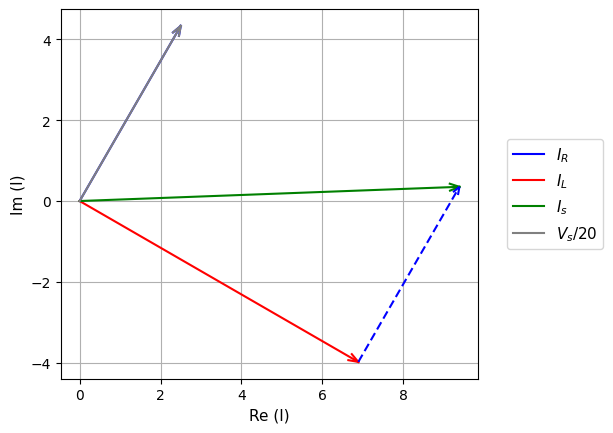

```python
import numpy as np
import gseim_calc as calc
import matplotlib.pyplot as plt
from matplotlib.ticker import (MultipleLocator, AutoMinorLocator)
from setsize import set_size

rad_to_deg = 180.0/np.pi

slv = calc.slv("phasor_11.in")

i_slv = 0
i_out = 0
filename = slv.l_filename_all[i_slv][i_out]
print('filename:', filename)
u = np.loadtxt(filename)

IR = slv.get_scalar_complex_1(i_slv, i_out, "IR_ac", u)
IL = slv.get_scalar_complex_1(i_slv, i_out, "IL_ac", u)
Is = slv.get_scalar_complex_1(i_slv, i_out, "Is_ac", u)
Vs = slv.get_scalar_complex_1(i_slv, i_out, "Vs_ac", u)

s_format = "%7.2f"

print('phasors in rectangular form:')

calc.print_complex_rect('IR', IR, s_format)
calc.print_complex_rect('IL', IL, s_format)
calc.print_complex_rect('Is', Is, s_format)
calc.print_complex_rect('Vs', Vs, s_format)

print('phasors in polar form:')

calc.print_complex_polar('IR', IR, s_format)
calc.print_complex_polar('IL', IL, s_format)
calc.print_complex_polar('Is', Is, s_format)
calc.print_complex_polar('Vs', Vs, s_format)

Vs1 = Vs/20.0

l_colors = ["blue", "red", "green", "grey", "dodgerblue", "tomato"]

l1 = []
l1_labels = []

color_IR  = calc.phasor_append_1a(l1, l1_labels, IR,  "$I_R$",    l_colors)
color_IL  = calc.phasor_append_1a(l1, l1_labels, IL,  "$I_L$",    l_colors)
color_Is  = calc.phasor_append_1a(l1, l1_labels, Is,  "$I_s$",    l_colors)
color_Vs1 = calc.phasor_append_1a(l1, l1_labels, Vs1, "$V_s/20$", l_colors)

theta_deg = 20.0
length_arrow = calc.phasor_3(l1, 0.02)
l1_arrow = calc.phasor_2(l1, theta_deg, length_arrow, 0.2)

l2 = []
l2_colors = []

calc.phasor_append_2(l2, l2_colors, IL, (IR + IL), color_IR)

l2_arrow = calc.phasor_2(l2, theta_deg, length_arrow, 0.2)

fig, ax = plt.subplots()
ax.set_aspect('equal', adjustable='box')
ax.grid()

for i, l_dummy in enumerate(l1_arrow):
    for k, t in enumerate(l_dummy):
        if (k == 0):
            ax.plot(t[0],t[1], color=l_colors[i], label=l1_labels[i])
        else:
            ax.plot(t[0],t[1], color=l_colors[i])

for i, l_dummy in enumerate(l2_arrow):
    for k, t in enumerate(l_dummy):
        ax.plot(t[0],t[1], color=l2_colors[i], linestyle='--', dashes=(4, 2))

calc.revise_axis_limits_1(ax, 3.0)
ax.legend(loc='center left', fontsize=11, bbox_to_anchor=(1.05, 0.5))

plt.xlabel('Re (I)', fontsize=11)
plt.ylabel('Im (I)', fontsize=11)
plt.show()
```

```
filename: phasor_11_2.dat
phasors in rectangular form:
SR: ( 250.00,   -0.00)
SL: (   0.00,  397.89)
SVs: ( 250.00,  397.89)
phasors in polar form:
SR: magnitude:  250.00, angle:   -0.00 deg
SL: magnitude:  397.89, angle:   90.00 deg
SVs: magnitude:  469.91, angle:   57.86 deg
```

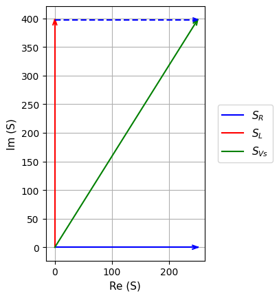

```python
import numpy as np
import gseim_calc as calc
import matplotlib.pyplot as plt
from matplotlib.ticker import (MultipleLocator, AutoMinorLocator)
from setsize import set_size

rad_to_deg = 180.0/np.pi

slv = calc.slv("phasor_11.in")

i_slv = 0
i_out = 1
filename = slv.l_filename_all[i_slv][i_out]
print('filename:', filename)
u = np.loadtxt(filename)
SR  = slv.get_scalar_complex_1(i_slv, i_out, "S_R",  u)
SL  = slv.get_scalar_complex_1(i_slv, i_out, "S_L",  u)
SVs = slv.get_scalar_complex_1(i_slv, i_out, "S_Vs", u)

s_format = "%7.2f"

print('phasors in rectangular form:')

calc.print_complex_rect('SR',  SR,  s_format)
calc.print_complex_rect('SL',  SL,  s_format)
calc.print_complex_rect('SVs', SVs, s_format)

print('phasors in polar form:')

calc.print_complex_polar('SR',  SR,  s_format)
calc.print_complex_polar('SL',  SL,  s_format)
calc.print_complex_polar('SVs', SVs, s_format)

l_colors = ["blue", "red", "green", "grey", "dodgerblue", "tomato"]

l1 = []
l1_labels = []

color_SR  = calc.phasor_append_1a(l1, l1_labels, SR,  "$S_R$",    l_colors)
color_SL  = calc.phasor_append_1a(l1, l1_labels, SL,  "$S_L$",    l_colors)
color_SVs = calc.phasor_append_1a(l1, l1_labels, SVs, "$S_{Vs}$", l_colors)

theta_deg = 20.0
length_arrow = calc.phasor_3(l1, 0.02)
l1_arrow = calc.phasor_2(l1, theta_deg, length_arrow, 0.2)

l2 = []
l2_colors = []

calc.phasor_append_2(l2, l2_colors, SL, (SL + SR), color_SR)

l2_arrow = calc.phasor_2(l2, theta_deg, length_arrow, 0.2)

fig, ax = plt.subplots()
#ax.set_aspect('equal', adjustable='box')
ax.set_aspect('equal')
ax.grid()

for i, l_dummy in enumerate(l1_arrow):
    for k, t in enumerate(l_dummy):
        if (k == 0):
            ax.plot(t[0],t[1], color=l_colors[i], label=l1_labels[i])
        else:
            ax.plot(t[0],t[1], color=l_colors[i])

for i, l_dummy in enumerate(l2_arrow):
    for k, t in enumerate(l_dummy):
        ax.plot(t[0],t[1], color=l2_colors[i], linestyle='--', dashes=(4, 2))

calc.revise_axis_limits_1(ax, 3.0)
ax.legend(loc='center left', fontsize=11, bbox_to_anchor=(1.05, 0.5))

plt.xlabel('Re (S)', fontsize=11)
plt.ylabel('Im (S)', fontsize=11)
plt.show()
```

[output not shown]

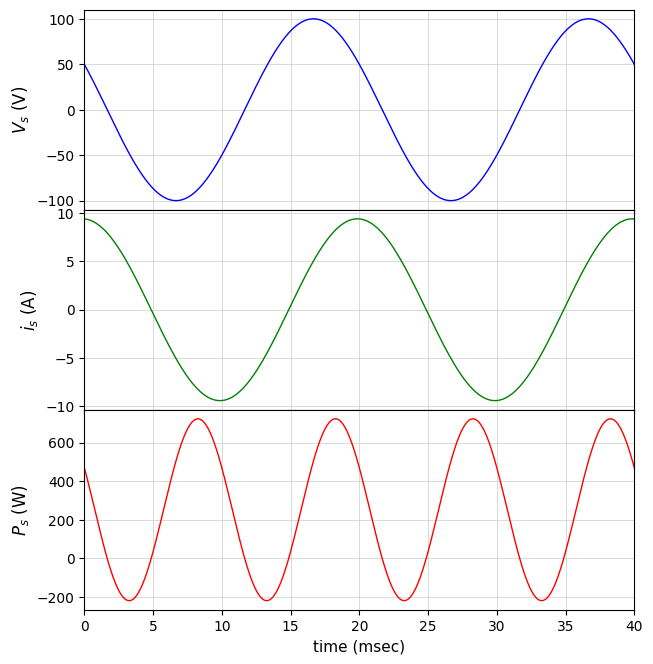

```python
import numpy as np
import matplotlib.pyplot as plt
import gseim_calc as calc
from setsize import set_size

slv = calc.slv("phasor_11.in")

i_slv = 1
i_out = 0
filename = slv.l_filename_all[i_slv][i_out]
print('filename:', filename)
u = np.loadtxt(filename)

t = u[:, 0]
t_end = t[-1]

i_Vs = slv.get_array_double(i_slv, i_out, 'i_Vs', u)
v_Vs = slv.get_array_double(i_slv, i_out, 'v_Vs', u)
P_Vs = slv.get_array_double(i_slv, i_out, 'P_Vs', u)

l1 = calc.min_max_1(t, P_Vs, 0.0, t_end)
print('min P_Vs:', "%7.2f"%l1[0])
print('max P_Vs:', "%7.2f"%l1[1])

color1='blue'
color2='green'
color3='red'

fig, ax = plt.subplots(3, sharex=False)
plt.subplots_adjust(wspace=0, hspace=0.0)

set_size(5.5, 6.0, ax[0])

for i in range(3):
    ax[i].set_xlim(left=0.0, right=t_end*1e3)
    ax[i].grid(color='#CCCCCC', linestyle='solid', linewidth=0.5)

ax[0].set_ylabel(r'$V_s$ (V)', fontsize=12)
ax[1].set_ylabel(r'$i_s$ (A)', fontsize=12)
ax[2].set_ylabel(r'$P_s$ (W)', fontsize=12)

for i in range(2):
    ax[i].tick_params(labelbottom=False)

ax[0].plot(t*1e3, v_Vs, color=color1, linewidth=1.0, label="$V_s$")
ax[1].plot(t*1e3, i_Vs, color=color2, linewidth=1.0, label="$i_s$")
ax[2].plot(t*1e3, P_Vs, color=color3, linewidth=1.0, label="$P_s$")

ax[2].set_xlabel('time (msec)', fontsize=11)

#plt.tight_layout()
plt.show()
```

This notebook was contributed by **Prof. Nakul Narayanan K**, Govt. Engineering College, Thrissur. He may be contacted at nakul@gectcr.ac.in.